# Part II - Prosper Loan Data Explanatory Analysis

## by Egwuda Ojonugwa

## Overview

- Prosper is a lending platform that provides loans to borrowers.
- The purpose of this analysis was to access the demography of borrowers like state, occupation, employment status and investigate for pointers to the loan amount granted to borrowers, what determined the amount borrowers could get, if there was any relationship between other variables and the loan amount.
- To qualify applicants, the company uses a proprietary rating system that considers Key data points like employment status, income, and debt-to-income ratio. Borrowers are then assigned a Prosper score from which investors usilize to determine loans to fund.

## Dataset

The dataset comprises information on 113,937 Prosper loans, each with 81 variables.

The variables include Term, loan interest rate, employment status, occupation income etc.

After variable selection and Data wrangling, 83,982 loan records and 18 variables remained for analysis.

## Borrowers Motivation

For what reason do people take loans? For some people it's a way of life, for others it is borne out of necessity and others are against borrow unless it's a matter of life and death. Analysis of Prosper loan data reveals the motivation of its audience towards loans.

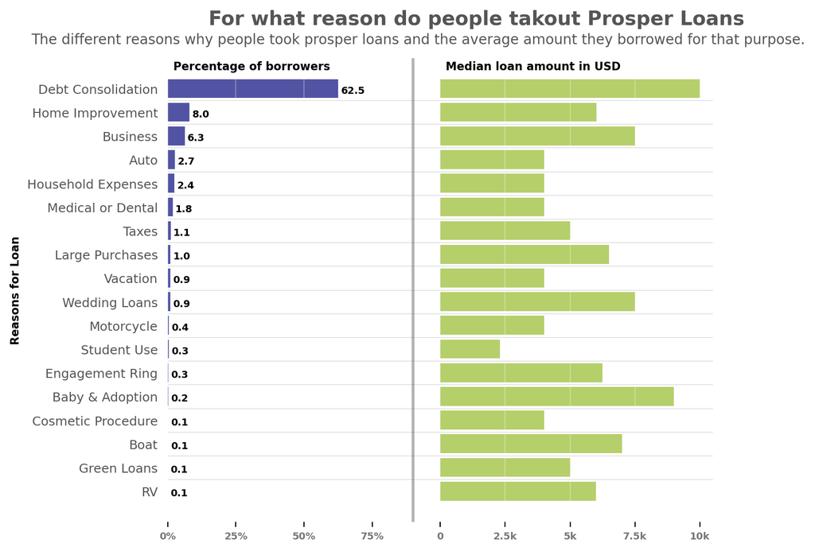

## For what reason do people takout Prosper Loans?

Over 60% of borrowers apply for prosper loans with reason being 'Debt Consolidation' ie Taking out one loan to pay off many others and it accounts for the highest amount loaned out on avaerage 10,000 USD. Other top reasons for taking loans are Home improvemnet, Business and Auto.

Baby & Adoption, Wedding Loans and Large Purchases also have High amount loaned on average in USD, which means borrowers depend on heaavy loans to finance their lifestyles.

## Borrowers Demography

The demography of the borrowers says alot about who they are and what they are into. We will show their state and occupation, and limit to the top 10.

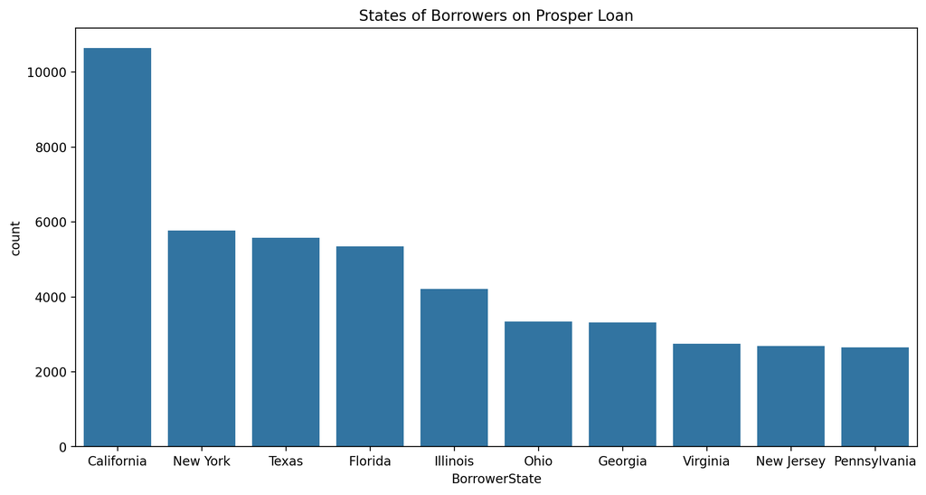

Most of the borrowers are from California, New York and Texas. According to an article on [Financebuzz](https://financebuzz.com/most-expensive-states-to-live#:~:text=Hawaii&text=Life%20in%20paradise%20comes%20at,at%20twice%20the%20national%20average.), These are some of the most expensive states to live in the USA and this maybe why people there are borrowing.

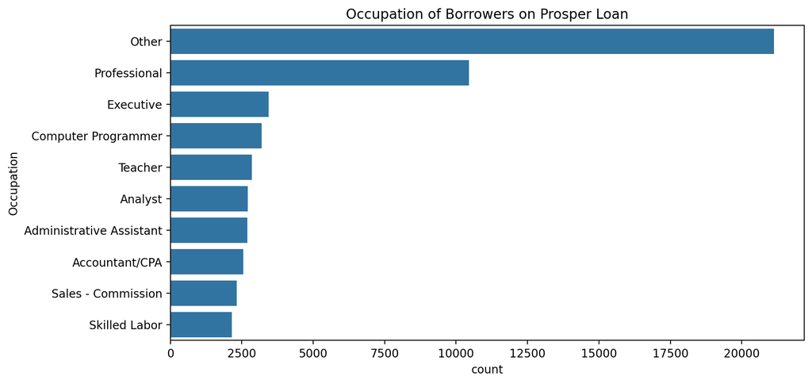

Professionals, Executives and Computer Programmers are the Top occupations of borrowers that take the most loans.

## Employment Status of the Borrrowers

Taking further dive into employment status and income range so as to gain insight from finances of the borrowers.

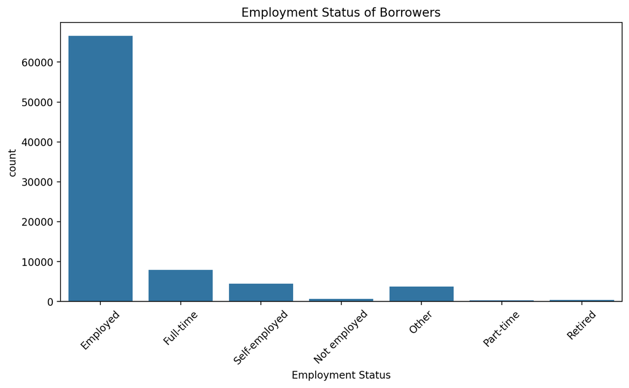

A large proportion of the borrowers are employed or have a full time job. The amount of people who are self employed is relatively low condering the fact that Business is the Top 3 reason for taking out loans. People between the 25k-75k income range take the most loans as we can see in the plot below.

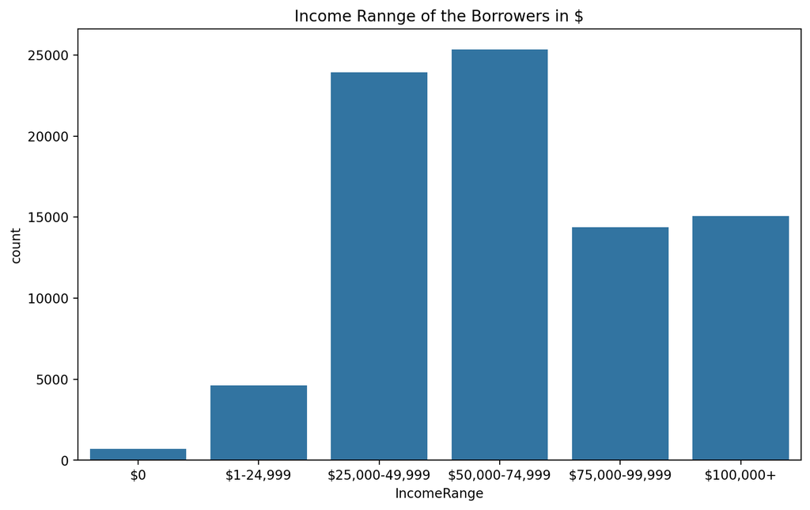

The plot above shows that borrowers within the income range of 25,000 - 74,999 take out the most loans as compared to the other income ranges.

## Relationship between BorrowerAPR, LoanOriginalAmount, and ProsperRating

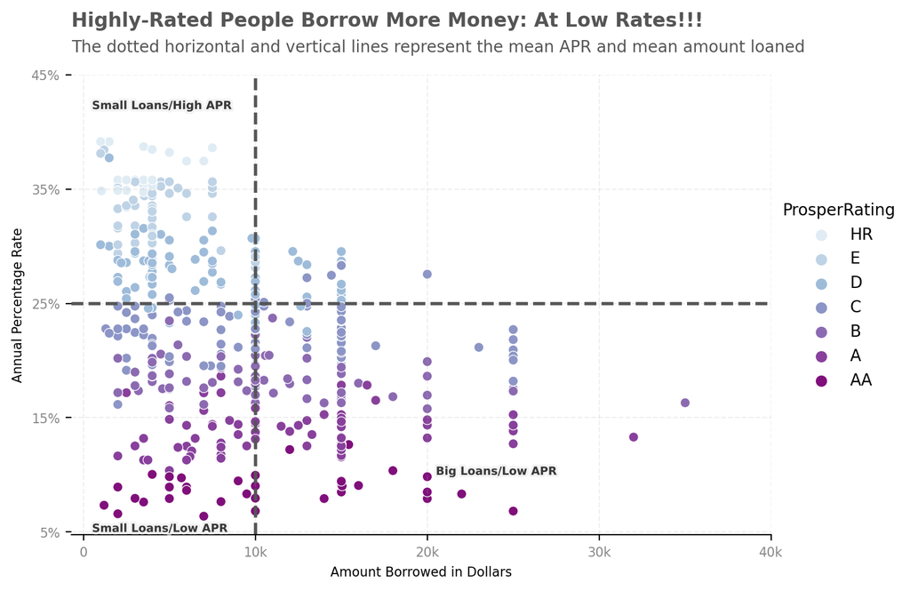

From the above plot, borrowers with high prosper ratings borrow small and large amounts while also maintaining low interest rates: this gives them a higher borrowing power on the platform.

With the average borrower rate at 25%, and the average amount loaned on the platform at 10,000 USD, low rated borrowers pay higher than average rates, even when getting small loans.